# Python数据处理

## 11. Python并行计算

主讲人：丁平尖

## Python并行计算

- 多线程（Multithreading）：
  - Python 中的多线程是指在同一个进程中创建多个线程，每个线程执行不同的任务。由于 Python 的全局解释器锁（GIL），多线程在 CPU 密集型任务中并不能真正实现并行执行。
- 多进程（Multiprocessing）：
  - Python 中的多进程是指创建多个进程，每个进程执行不同的任务。由于每个进程有自己的内存空间，多进程可以真正实现并行执行。

## CPU 密集型任务和 IO 密集型任务

- CPU密集型
  - CPU密集型也叫计算密集型，是指I/O在很短时间就可以完成，CPU需要大量的计算和处理，特点是CPU占用率相当高
  - 例如：压缩解压缩，加密解密，正则表达式搜索
- IO密集型
  - IO密集型指的是系统运行大部分的状况是CPU在等IO的读写操作，CPU占用率很低
  - 例如：文件处理程序，网络爬虫程序，读写数据库程序

## Python速度慢的原因

- 对性能要求高的模块不会使用python开发
- Python速度慢的原因
  - 动态类型语言，随时检查类型
  - 边解释边执行
  - GIL（全局解释器锁）：无法利用多核CPU并发执行

## 全局解释器锁GIL

- 全局解释器锁（Global Interpreter Lock，缩写GIL）
- 是程序设计语言解释器用于同步线程的一种机制，它使得任何时刻仅有一个线程在执行。即便在多核心处理器尚，使用GIL的解释器也只允许同一时间执行一个线程。
- http://www.dabeaz.com/python/UnderstandingGIL.pdf
  - When a thread is running, it holds the GIL
  - GIL released on I/O (read,write,send,recv,etc.)

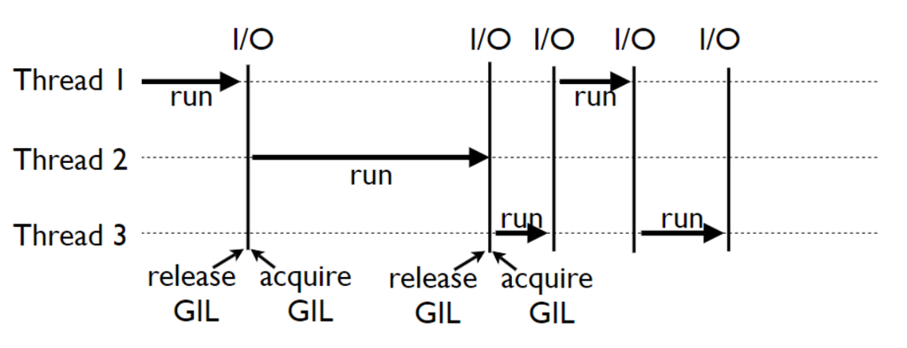

## Python创建多线程的方法

- 怎么创建一个线程
  - `t = threading.Thread(target=my_func, args=())`
- 启动线程
  - `t.start()`
- 等待结束
  - `t.join()`
  - 当你创建一个线程并启动它时，主线程会继续执行，而新创建的线程会在后台运行。如果你不使用 `join()` 方法，主线程可能会在新线程结束之前就退出这会导致以下问题：
    - 资源泄漏：如果主线程退出，而新线程还在运行，新线程可能会占用系统资源，导致资源泄漏。
    - 数据不一致：如果主线程退出，而新线程还在运行，新线程可能会修改共享数据，而主线程已经退出，导致数据不一致。

```python
import threading
import time
def new_thread():
    time.sleep(0.1)
    print("new thread")

t = threading.Thread(target=new_thread)
t.start()
# t.join()
print("main thread")
```

```
main thread
new thread
```

```python
t = threading.Thread(target=new_thread)
t.start()
t.join()
print("main thread")
```

```
new thread
main thread
```

```python
import urllib.request
urls = [f"https://pubmed.ncbi.nlm.nih.gov/?term=machine%20learning&page={page}" for page in range(1, 50+1)]

def craw(url):
    r = urllib.request.urlopen(url)
    return(r.read())

urls[0], len(craw(urls[0]))
```

```
('https://pubmed.ncbi.nlm.nih.gov/?term=machine%20learning&page=1', 282652)
```

```python
def single_thread():
    for url in urls:
        craw(url)

import threading
def multi_thread():
    threads = [threading.Thread(target=craw, args=(url,)) for url in urls]
    for t in threads:
        t.start()
    for t in threads:
        t.join()

import time
start = time.time()
single_thread()
end = time.time()
print("single thread cost", end - start)
start = time.time()
multi_thread()
end = time.time()
print("multi thread cost", end - start)
```

```
single thread cost 57.911908864974976
multi thread cost 2.104243755340576
```

## 生产者消费者爬虫的架构

- 配置不同的资源，如线程数

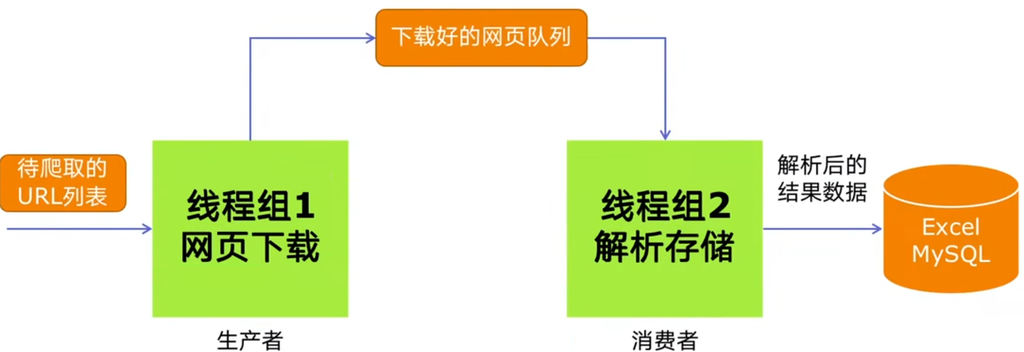

## 多线程数据通信的`queue.Queue`

- `queue.Queue`可以用于多线程之间的，线程安全的数据通信
- 导入类库：`import queue`
- 创建Queue
  - `q = queue.Queue()`
- 添加元素
  - `q.put(item)`
- 获取元素
  - `item = q.get()`
- 查询状态
  - 查看元素的多少：`q.qsize()`
  - 判断是否为空：`q.empty()`
  - 判断是否已满：`q.full()`

```python
import re
from bs4 import BeautifulSoup
def craw(url):
    r = urllib.request.urlopen(url)
    return r.read()

def parse(html):
    soup = BeautifulSoup(html, 'html.parser')
    links = soup.find_all('a', attrs={"class": "docsum-title"})
    return [(link['href'], re.sub(r'^[\s]+|\B\s+\B', '', link.text)) for link in links]
```

```python
html = craw(urls[0])
links = parse(html)
links
```

```
[('/34518686/', 'A guide to machine learning for biologists.'),
 ('/26572668/', 'Machine Learning in Medicine.'),
 ('/32704420/',
  'Introduction to Machine Learning, Neural Networks, and Deep Learning.'),
 ('/30102808/', 'eDoctor: machine learning and the future of medicine.'),
 ('/32800297/', 'Supervised Machine Learning: A Brief Primer.'),
 ('/34338485/', 'Machine learning for cardiology.'),
 ('/33290932/',
  'Machine learning model for predicting malaria using clinical information.'),
 ('/32011262/',
  'A Review on Machine Learning for EEG Signal Processing in Bioengineering.'),
 ('/31539636/',
  'Machine learning for clinical decision support in infectious diseases: a narrative review of current applications.'),
 ('/31818379/', 'Machine Learning Principles for Radiology Investigators.')]
```

```python
import queue
import threading
# 生产者
def do_craw(url_queue: queue.Queue, html_queue: queue.Queue):
    while True:
        url = url_queue.get()
        html = craw(url)
        html_queue.put(html)

def do_parse(html_queue: queue.Queue, fout):
    while True:
        html = html_queue.get()
        results = parse(html)
        for result in results:
            fout.write(str(result) + '\n')
```

```python
url_queue = queue.Queue()
html_queue = queue.Queue()

for url in urls:
    url_queue.put(url)

for idx in range(3):
    t = threading.Thread(target=do_craw, args=(url_queue, html_queue))
    t.start()

fout = open("tmp.txt", "w")
for idx in range(2):
    t = threading.Thread(target=do_parse, args=(html_queue, fout))
    t.start()
```

```python
!cat tmp.txt
```

```
('/25692180/', 'Machine learning for medical applications.')
('/35953649/', 'Self-supervised learning in medicine and healthcare.')
('/34450960/', 'Machine Learning Enhances the Performance of Bioreceptor-Free Biosensors.')
('/34585185/', 'Machine learning and chemometrics for electrochemical sensors: moving forward to the future of analytical chemistry.')
('/34731480/', 'Machine Learning from Omics Data.')
('/36124599/', 'Machine fault detection methods based on machine learning algorithms: A review.')
('/33826964/', 'Basic of machine learning and deep learning in imaging for medical physicists.')
('/34302331/', 'The Utility of Unsupervised Machine Learning in Anatomic Pathology.')
('/38565358/', 'Applications of machine learning in phylogenetics.')
('/34203119/', 'An Overview of Machine Learning within Embedded and Mobile Devices-Optimizations and Applications.')
('/34518686/', 'A guide to machine learning for biologists.')
('/26572668/', 'Machine Learning in Medicine.')
('/32704420/', 'Introduction to Machine Learning, Neural Networks, and Deep Learning.')
('/30102808/', 'eDoctor: machine learning and the future of medicine.')
('/32800297/', 'Supervised Machine Learning: A Brief Primer.')
('/34338485/', 'Machine learning for cardiology.')
('/33290932/', 'Machine learning model for predicting malaria using clinical information.')
('/32011262/', 'A Review on Machine Learning for EEG Signal Processing in Bioengineering.')
('/31539636/', 'Machine learning for clinical decision support in infectious diseases: a narrative review of current applications.')
('/31818379/', 'Machine Learning Principles for Radiology Investigators.')
('/32449232/', 'The use of artificial intelligence, machine learning and deep learning in oncologic histopathology.')
('/33185417/', 'Advancing Biosensors with Machine Learning.')
('/38079572/', 'Evaluating Machine Learning Methods of Analyzing Multiclass Metabolomics.')
('/36222893/', 'Supervised machine learning and associated algorithms: applications in orthopedic surgery.')
('/33036008/', 'Supervised machine learning tools: a tutorial for clinicians.')
('/34392886/', 'Machine Learning, Deep Learning, and Closed Loop Devices-Anesthesia Delivery.')
('/30609102/', 'Machine learning in suicide science: Applications and ethics.')
('/38057999/', 'Review of machine learning and deep learning models for toxicity prediction.')
('/32645448/', 'Machine learning and AI-based approaches for bioactive ligand discovery and GPCR-ligand recognition.')
('/32245523/', 'Machine learning and clinical epigenetics: a review of challenges for diagnosis and classification.')
('/33316137/', 'Machine learning for predictive data analytics in medicine: A review illustrated by cardiovascular and nuclear medicine examples.')
('/30971806/', 'Deep learning: new computational modelling techniques for genomics.')
('/35830864/', 'Machine-designed biotherapeutics: opportunities, feasibility and advantages of deep learning in computational antibody discovery.')
('/34537858/', 'Radiomics, machine learning, and artificial intelligence-what the neuroradiologist needs to know.')
('/32456690/', 'How machine learning could be used in clinical practice during an epidemic.')
('/30903692/', 'Simulation-assisted machine learning.')
('/33840471/', 'Deus ex machina? Demystifying rather than deifying machine learning.')
('/32517778/', 'The use of machine learning in rare diseases: a scoping review.')
('/34092975/', 'State of machine and deep learning in histopathological applications in digestive diseases.')
('/37177382/', 'A Comprehensive Review on Machine Learning in Healthcare Industry: Classification, Restrictions, Opportunities and Challenges.')
```

[output cut: 28 more lines]

```
('/35891045/', 'Machine Learning Methods for Hypercholesterolemia Long-Term Risk Prediction.')
('/33431591/', 'What machine learning can do for developmental biology.')
('/38847379/', 'Brain Disorder Detection and Diagnosis using Machine Learning and Deep Learning - A Bibliometric Analysis.')
('/33916850/', 'A Review of Recent Deep Learning Approaches in Human-Centered Machine Learning.')
('/34545817/', 'Towards Interpretable Machine Learning in EEG Analysis.')
('/31427808/', 'Do no harm: a roadmap for responsible machine learning for health care.')
('/37420672/', 'Terrain Characterization via Machine vs. Deep Learning Using Remote Sensing.')
('/34814265/', 'Exploration of machine algorithms based on deep learning model and feature extraction.')
('/29934890/', 'Machine Learning Methods in Computational Toxicology.')
('/35161928/', 'Multi-Label Active Learning-Based Machine Learning Model for Heart Disease Prediction.')
('/34837786/', 'Machine learning and deep learning enabled fuel sooting tendency prediction from molecular structure.')
('/37087255/', 'Machine learning and deep learning based on the small FT-MIR dataset for fine-grained sampling site recognition of boletus tomentipes.')
('/36460741/', 'Application of machine learning in the diagnosis of vestibular disease.')
('/35743052/', 'Editorial of Special Issue "Deep Learning and Machine Learning in Bioinformatics".')
('/35141903/', 'Hybrid machine learning classification scheme for speaker identification.')
```

## 线程锁

```python
import threading
import time
import logging
logging.basicConfig(level=logging.DEBUG, format='%(asctime)s - %(levelname)s - %(message)s')

class Account:
    def __init__(self, balance):
        self.balance = balance

def draw(account, draw_amount):
    if account.balance >= draw_amount:
        time.sleep(0.1)
        logging.info(f"{threading.current_thread().name}: 取钱成功")
        account.balance -= draw_amount
        logging.info(f"{threading.current_thread().name}: 余额: {account.balance}")
    else:
        logging.info(f"{threading.current_thread().name}: 取钱失败，余额不足")
```

```python
account = Account(1000)
ta = threading.Thread(name="ta", target=draw, args=(account, 800))
tb = threading.Thread(name="tb", target=draw, args=(account, 800))

ta.start()
tb.start()
```

```
2024-11-06 09:33:23,545 - INFO - ta: 取钱成功
2024-11-06 09:33:23,546 - INFO - tb: 取钱成功
2024-11-06 09:33:23,546 - INFO - ta: 余额: 200
2024-11-06 09:33:23,547 - INFO - tb: 余额: -600
```

```python
import threading
import time

lock = threading.Lock()

class Account:
    def __init__(self, balance):
        self.balance = balance

def draw(account, draw_amount):
    with lock:
        if account.balance >= draw_amount:
            time.sleep(0.1)
            logging.info(f"{threading.current_thread().name}, 取钱成功")
            account.balance -= draw_amount
            logging.info(f"{threading.current_thread().name},余额: {account.balance}")
        else:
            logging.info(f"{threading.current_thread().name}, 取钱失败，余额不足")
```

```python
account = Account(1000)
ta = threading.Thread(name="ta", target=draw, args=(account, 800))
tb = threading.Thread(name="tb", target=draw, args=(account, 800))

ta.start()
tb.start()
```

```
2024-11-06 09:34:12,429 - INFO - ta, 取钱成功
2024-11-06 09:34:12,430 - INFO - ta,余额: 200
2024-11-06 09:34:12,430 - INFO - tb, 取钱失败，余额不足
```

## 线程池

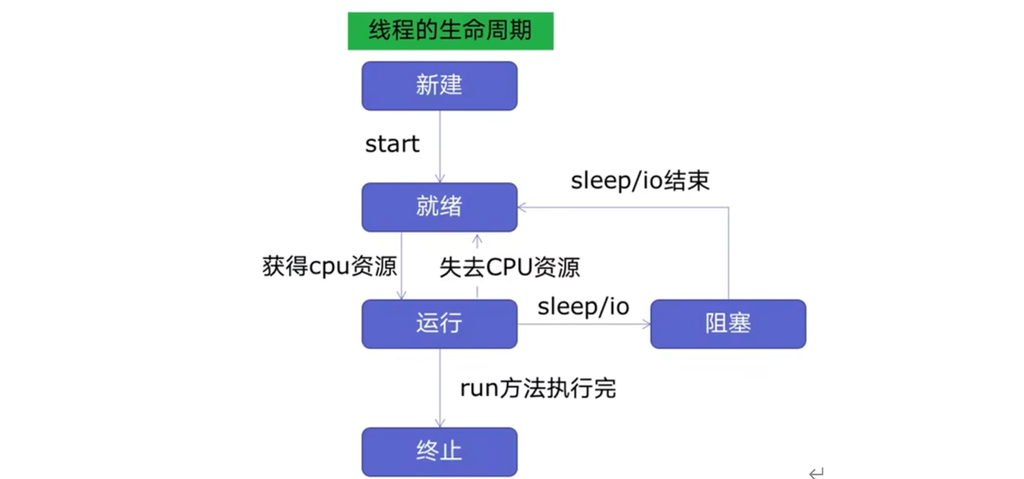

- 新建线程系统需要分配资源，终止线程系统需要回收资源，如果可以重用线程，则可以减去新建/终止的开销

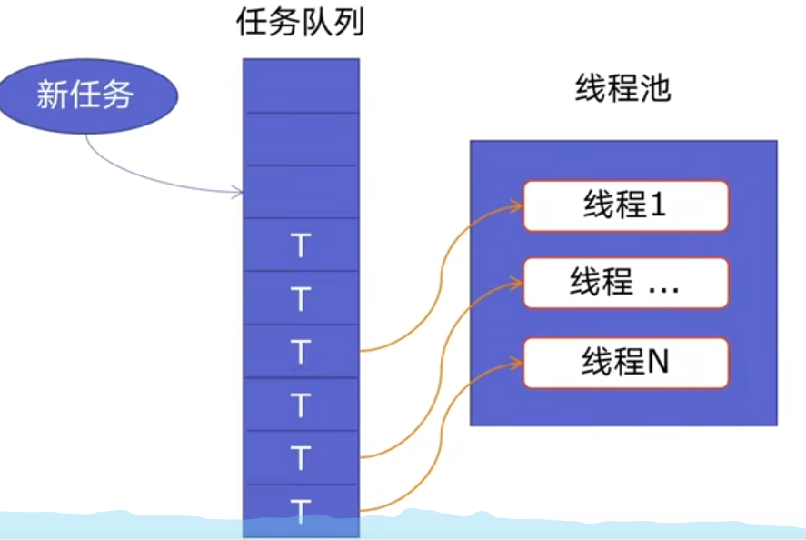

# 使用线程池的好处

- 提升性能：因为减去大量新建，终止线程的开销，重用了线程资源
- 适用场景：适合处理突发性大量请求或需要大量线程完成任务，但实际任务处理时间较短
- 防御功能：能有效避免系统因为创建线程过多，而导致负荷过大响应变慢等问题
- 代码优势：使用线程池的语法比自己新建线程执行线程更加简洁

## threading中的线程池: ThreadPoolExecutor

```python
from concurrent.futures import ThreadPoolExecutor

with ThreadPoolExecutor() as executor:
    print(executor._max_workers)
    htmls = executor.map(craw, urls)

with ThreadPoolExecutor() as pool:
    results = pool.map(parse, htmls)

    for result in results:
        print(result)
```

```
20
[('/34518686/', 'A guide to machine learning for biologists.'), ('/26572668/', 'Machine Learning in Medicine.'), ('/32704420/', 'Introduction to Machine Learning, Neural Networks, and Deep Learning.'), ('/30102808/', 'eDoctor: machine learning and the future of medicine.'), ('/32800297/', 'Supervise…
[('/32449232/', 'The use of artificial intelligence, machine learning and deep learning in oncologic histopathology.'), ('/33185417/', 'Advancing Biosensors with Machine Learning.'), ('/38079572/', 'Evaluating Machine Learning Methods of Analyzing Multiclass Metabolomics.'), ('/36222893/', 'Supervis…
[('/25692180/', 'Machine learning for medical applications.'), ('/35953649/', 'Self-supervised learning in medicine and healthcare.'), ('/34450960/', 'Machine Learning Enhances the Performance of Bioreceptor-Free Biosensors.'), ('/34585185/', 'Machine learning and chemometrics for electrochemical se…
[('/33316137/', 'Machine learning for predictive data analytics in medicine: A review illustrated by cardiovascular and nuclear medicine examples.'), ('/30971806/', 'Deep learning: new computational modelling techniques for genomics.'), ('/35830864/', 'Machine-designed biotherapeutics: opportunities…
[('/32804360/', 'Machine Learning for Biomedical Time Series Classification: From Shapelets to Deep Learning.'), ('/35026457/', 'Uncharted Waters of Machine and Deep Learning for Surgical Phase Recognition in Neurosurgery.'), ('/37080758/', 'Using traditional machine learning and deep learning metho…
[('/34967861/', 'Machine Learning-Based Anomaly Detection Techniques in Ophthalmology.'), ('/38383870/', 'A Review of Machine Learning Algorithms for Biomedical Applications.'), ('/38156410/', 'Machine learning (ML) techniques as effective methods for evaluating hair and skin assessments: A systemat…
[('/35821601/', 'Unsupervised and semi-supervised learning: the next frontier in machine learning for plant systems biology.'), ('/36085353/', 'Machine learning in project analytics: a data-driven framework and case study.'), ('/30100821/', 'Machine learning: supervised methods.'), ('/37552450/', 'A…
[('/36460741/', 'Application of machine learning in the diagnosis of vestibular disease.'), ('/35743052/', 'Editorial of Special Issue "Deep Learning and Machine Learning in Bioinformatics".'), ('/35141903/', 'Hybrid machine learning classification scheme for speaker identification.'), ('/38287813/'…
[('/38847379/', 'Brain Disorder Detection and Diagnosis using Machine Learning and Deep Learning - A Bibliometric Analysis.'), ('/33916850/', 'A Review of Recent Deep Learning Approaches in Human-Centered Machine Learning.'), ('/34545817/', 'Towards Interpretable Machine Learning in EEG Analysis.'),…
[('/35957366/', 'Machine Learning Models for Enhanced Estimation of Soil Moisture Using Wideband Radar Sensor.'), ('/35126955/', 'Application of Machine Learning in Rheumatic Immune Diseases.'), ('/35140765/', 'Developing Multiagent E-Learning System-Based Machine Learning and Feature Selection Tech…
[('/36720809/', 'Applying Machine Learning to Classify the Origins of Gene Duplications.'), ('/35591194/', 'Rainfall Prediction System Using Machine Learning Fusion for Smart Cities.'), ('/34320410/', 'Probing machine-learning classifiers using noise, bubbles, and reverse correlation.'), ('/32978734…
[('/36080927/', 'Machine Learning and Lexicon Approach to Texts Processing in the Detection of Degrees of Toxicity in Online Discussions.'), ('/36576347/', 'Do You See What I See? Automated IFE Interpretation Using Machine Learning.'), ('/38633744/', 'Exploring the impact of pathogenic microbiome in…
[('/39325602/', 'A Scoping Review of Machine Learning Applied to Peripheral Nerve Interfaces.'), ('/32049317/', 'ColocML: machine learning quantifies co-localization between mass spectrometry images.'), ('/33902993/', 'Skin tear classification using machine learning from digital RGB image.'), ('/348…
```

[output cut: 37 more lines]

## 多进程multiprocessing

- 如果遇到了CPU密集型计算，多线程反而会降低执行速度
- multiprocessing模块解决了GIL缺陷，用多进程在多CPU上并行执行

## multiprocessing和threading对比

| 语法条目 | 多线程 | 多进程 |
| --- | --- | --- |
| 引入模块 | `from threading import Thread` | `from multiprocessing import Process` |
| 新建 | `t=Thread(target=func, args=(100,))` | `p=Process(target=f, args=('bob',))` |
| 启动 | `t.start()` | `p.start()` |
| 等待结束 | `t.join()` | `p.join()` |
| 通信 | `import queue` `q=queue.Queue()` `q.put(item)` `item=q.get()` | `from multiprocessing import Queue` `q=Queue()` `q.put([42, None, 'hello'])` `item=q.get()` |

| 语法条目 | 多线程 | 多进程 |
| --- | --- | --- |
| 安全加锁 | `from threading import Lock` `lock=Lock()` `with lock:` `# do somthing` | `from multiprocessing import Lock` `lock=Lock()` `with lock:` `# do something` |
| 池化技术 | `from concurrent.futures import ThreadPoolExecutor` `with ThreadPoolExecutor() as executor:` `results=executor.map(func, [1,2,3])` | `from concurrent.futures import ProcessPoolExecutor` `with ProcessPoolExecutor() as executor:` `results=executor.map(func, [1,2,3]`) |

## 对于CPU密集任务，单线程，多线程和多进程对比

```python
import math
from concurrent.futures import ThreadPoolExecutor
from concurrent.futures import ProcessPoolExecutor

def is_prime(number):
    if number < 2:
        return False
    if number == 2:
        return True
    else:
        ulim = math.ceil(math.sqrt(number))
        for k in range(3, ulim + 1, 2):
            if number % k == 0:
                return False
        return True
```

```python
import random

def generate_random_numbers(count):
    numbers = []
    for i in range(count):
        number = random.randint(10**15, (10**16) - 1)
        numbers.append(number)
    return numbers

PRIMES = generate_random_numbers(200)
```

```python
def single_thread():
    for number in PRIMES:
        is_prime(number)

def multi_thread():
    with ThreadPoolExecutor() as executor:
        results = executor.map(is_prime, PRIMES)

def multi_process():
    with ProcessPoolExecutor() as pool:
        results = pool.map(is_prime, PRIMES)

start = time.time()
multi_thread()
end = time.time()
print("multi thread cost", end - start)
start = time.time()
single_thread()
end = time.time()
print("single thread cost", end - start)
start = time.time()
multi_process()
end = time.time()
print("multi process cost", end - start)
```

```
multi thread cost 16.63011908531189
single thread cost 16.05925965309143
multi process cost 4.866028547286987
```

- 由于GIL的存在，多线程比单线程计算的还慢，而多进程可以明显加快执行速度